[figure not shown]

# Satellite Management Controller

Version: 1.0.0

Date: 2024-04-11

Document Status: Draft

Document Language: en-US

Copyright Notice  
Copyright © 2024 OCP. All rights reserved.

NOTWITHSTANDING THE ENCLOSED LICENSES, THIS SPECIFICATION IS PROVIDED BY OCP "AS IS" AND OCP EXPRESSLY DISCLAIMS ANY WARRANTIES (EXPRESS, IMPLIED, OR OTHERWISE), INCLUDING IMPLIED WARRANTIES OF MERCHANTABILITY, NON-INFRINGEMENT, FITNESS FOR A PARTICULAR PURPOSE, OR TITLE, RELATED TO THE SPECIFICATION. NOTICE IS HEREBY GIVEN, THAT OTHER RIGHTS NOT GRANTED AS SET FORTH ABOVE, INCLUDING WITHOUT LIMITATION, RIGHTS OF THIRD PARTIES WHO DID NOT EXECUTE THE ABOVE LICENSES, MAY BE IMPLICATED BY THE IMPLEMENTATION OF OR COMPLIANCE WITH THIS SPECIFICATION.

OCP IS NOT RESPONSIBLE FOR IDENTIFYING RIGHTS FOR WHICH A LICENSE MAY BE REQUIRED IN ORDER TO IMPLEMENT THIS SPECIFICATION. THE ENTIRE RISK AS TO IMPLEMENTING OR OTHERWISE USING THE SPECIFICATION IS ASSUMED BY YOU.

IN NO EVENT WILL OCP BE LIABLE TO YOU FOR ANY MONETARY DAMAGES WITH RESPECT TO ANY CLAIMS RELATED TO, OR ARISING OUT OF YOUR USE OF THIS SPECIFICATION, INCLUDING BUT NOT LIMITED TO ANY LIABILITY FOR LOST PROFITS OR ANY CONSEQUENTIAL, INCIDENTAL, INDIRECT, SPECIAL OR PUNITIVE DAMAGES OF ANY CHARACTER FROM ANY CAUSES OF ACTION OF ANY KIND WITH RESPECT TO THIS SPECIFICATION, WHETHER BASED ON BREACH OF CONTRACT, TORT (INCLUDING NEGLIGENCE), OR OTHERWISE, AND EVEN IF OCP HAS BEEN ADVISED OF THE POSSIBILITY OF SUCH DAMAGE.

CONTENTS

# 1 License

## 1.1 OPTION B: Open Web Foundation (OWF) CLA

Contributions to this Specification are made under the terms and conditions set forth in Modified OWF-CLA-1.0.2 (As of June 1, 2023) (“Contribution License”) by:

**Google**

> chadyoshikawa@google.com  
> edtanous@google.com

**HPE**

> jeff.hilland@hpe.com  
> gregg.shick@hpe.com

**Meta**

> patrickw3@fb.com

**Samsung**

> changho.c@samsung.com  
> kavin.lee@samsung.com  
> bj20.kim@samsung.com  
> mike.allison@samsung.com

Usage of this Specification is governed by the terms and conditions set forth in **Modified OWFa1.0.2 Final Specification Agreement (FSA) (As of June 1, 2023) (“Specification License”)**.

You can review the applicable Specification License(s) referenced above by the contributors to this Specification on the OCP website at http://www.opencompute.org/participate/legal-documents/. For actual executed copies of either agreement, please contact OCP directly.

**Notes:**

1. The above license does not apply to the Appendix or Appendices. The information in the Appendix or Appendices is for reference only and non-normative in nature.

NOTWITHSTANDING THE FOREGOING LICENSES, THIS SPECIFICATION IS PROVIDED BY OCP "AS IS" AND OCP EXPRESSLY DISCLAIMS ANY WARRANTIES (EXPRESS, IMPLIED, OR OTHERWISE), INCLUDING IMPLIED WARRANTIES OF MERCHANTABILITY, NON-INFRINGEMENT, FITNESS FOR A PARTICULAR PURPOSE, OR TITLE, RELATED TO THE SPECIFICATION. NOTICE IS HEREBY GIVEN, THAT OTHER RIGHTS NOT GRANTED AS SET FORTH ABOVE, INCLUDING WITHOUT LIMITATION, RIGHTS OF THIRD PARTIES WHO DID NOT EXECUTE THE ABOVE LICENSES, MAY BE IMPLICATED BY THE IMPLEMENTATION OF OR COMPLIANCE WITH THIS SPECIFICATION. OCP IS NOT RESPONSIBLE FOR IDENTIFYING RIGHTS FOR WHICH A LICENSE MAY BE REQUIRED IN ORDER TO IMPLEMENT THIS SPECIFICATION. THE ENTIRE RISK AS TO IMPLEMENTING OR OTHERWISE USING THE SPECIFICATION IS ASSUMED BY YOU. IN NO EVENT WILL OCP BE LIABLE TO YOU FOR ANY MONETARY DAMAGES WITH RESPECT TO ANY CLAIMS RELATED TO, OR ARISING OUT OF YOUR USE OF THIS SPECIFICATION, INCLUDING BUT NOT LIMITED TO ANY LIABILITY FOR LOST PROFITS OR ANY CONSEQUENTIAL, INCIDENTAL, INDIRECT, SPECIAL OR PUNITIVE DAMAGES OF ANY CHARACTER FROM ANY CAUSES OF ACTION OF ANY KIND WITH RESPECT TO THIS SPECIFICATION, WHETHER BASED ON BREACH OF CONTRACT, TORT (INCLUDING NEGLIGENCE), OR OTHERWISE, AND EVEN IF OCP HAS BEEN ADVISED OF THE POSSIBILITY OF SUCH DAMAGE.

# 2 Acknowledgements

The Contributors of this Specification would like to acknowledge the following companies for their feedback:

Hewlett Packard Enterprise  
Google  
Samsung  
Dell  
Meta

# 3 Compliance with OCP Tenants

## 3.1 Openness

The SMC V1.0 specification proposes an ecosystem-enabling set of requirements for peripherals to enable management compatibility between open systems. This allows interoperability between various device classes and host systems.

## 3.2 Efficiency

OEMs invest time to create specifications for industry Independent Hardware Vendors (IHVs) which must be implemented in order to support proper management by the host. IHVs invest time working with multiple OEMs to implement those requirements. The goal of the SMC specification is to standardize those various work streams into a single public OCP specification where both OEM and IHV can more effectively promulgate these requirements. Additionally, multi-vendor customer environments will benefit from the efficiencies achieved through increased device interoperability and the utilization of a common code base for system management.

## 3.3 Impact

The SMC represents a single set of OCP device manageability requirements allowing for IHV ease of development, time to market, and effective use of engineering resources. Device management ASICs could be developed allowing multiple IHVs to leverage a standardized SMC component providing consistent management across device classes.

## 3.4 Scale

Large scale deployments benefit from the standardization of management capability across multiple device classes, server and device vendors which this specification provides.

Redfish, RDE and PLDM DMTF standards for management are utilized allowing for a common set of APIs and management tools regardless of hardware or software environment or size of server deployment.

## 3.5 Sustainability

Between customers’ sustainability initiatives and demands to control energy consumption and costs, the ability to report, analyze and actuate server power usage data has become a key initiative.

The creation of a truly interoperable telemetry environment will allow businesses to datacenters, no matter the size, to more effectively meet sustainability targets. SMC thermal and power management capabilities can be utilized to enable this goal of minimizing power requirements and overall energy usage

# 4 Change Log

| Date | Version # | Author | Description |
| --- | --- | --- | --- |
| 7/5/2022 | 0.1 | Chad Yoshikawa | Filled in Title, Authors, Contributors and sections 1-3 |
| 10/1/2022 | 0.2 | Ed Tanous | Major reorganization. Rewrites to many sections |
| 4/27/2023 | 0.3 | Ed Tanous | Removal of old text, formatting cleanups |
| 9/15/2023 | 1.0 | Chad Yoshikawa | Used recent |
| 2/12/2024 | 1.0 | Gregg Shick | Convert to markdown |

# 5 Overview

The Satellite Management Controller specification defines a validatable management interface between a satellite container (“server” or more generally a “host”) and simple hardware plug-ins (“satellites”). For example, for a server and PCIe plug-in card, the host server manages the satellite plug-in.

Satellites are simple: they do not manage other devices and typically contain a single thermal, power and security domain. Note that the satellite and host may not be discrete hardware; host and satellite may be integrated onto the same board in the case of a tray and its SoC.

Satellite conformance can be validated using software tools, which enables independent hardware development and bring-up. To provide validation, the SMC specification defines a compatibility test suite (CTS) to ensure conformance to specified functional requirements.

The management interface additionally specifies SLOs for operations such as firmware update and power management operations. These SLOs may impose constraints on the underlying hardware. For example, timely firmware update may require i3c (vs. i2c) or higher-bandwidth management links.

## 5.1 Architectural Example

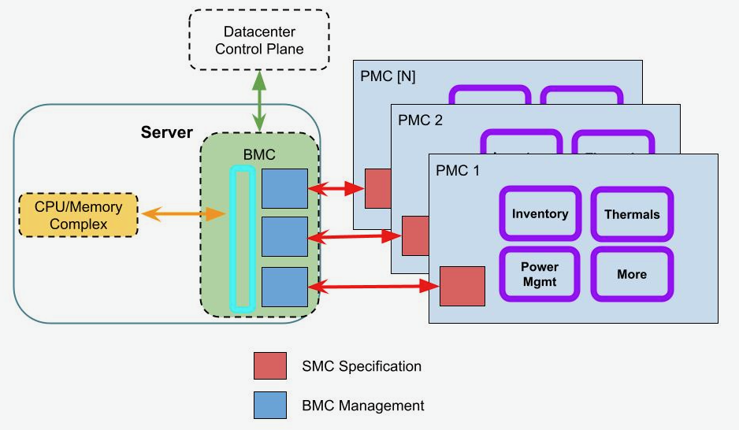

SMC includes all API definitions required for managing a peripheral device from an out of band management controller (BMC) in the most common configuration. While other configurations may exist that this specification fulfills, the above diagram is considered the baseline. This specification may reference elements of the baseline configuration as examples. Other configurations may exist.

The SMC specification explicitly does not define any physical connectors, physical form factors, or specifications for non SMC components, although other specifications (such as the [Modular Hardware Management DC-SCM](https://www.opencompute.org/documents/ocp-dc-scm-spec-rev-1-0-pdf)) may define connector specifications that may be used in deployments. For some examples, this specification may assume a PCIe 16X connector, and a single socket server with BMC.

# 6 Protocols

SMC devices *shall* implement DMTF DSP0236 ([Management Component Transport Protocol (MCTP) Base Specification](https://www.dmtf.org/dsp/DSP0236)).

## 6.1 Physical Bindings supported

Devices meeting this specification *shall* implement DMTF DSP0233 ([Management Component Transport Protocol (MCTP) I3C Transport Binding Specification](https://www.dmtf.org/dsp/DSP0233)) OR DSP0237 ([Management Component Transport Protocol (MCTP) SMBus/I2C Transport Binding Specification](https://www.dmtf.org/dsp/DSP0237)) OR DSP0238 ([Management Component Transport Protocol (MCTP) PCIe VDM Transport Binding Specification](https://www.dmtf.org/dsp/DSP0238)). Other physical bindings such as USB, that have MCTP bindings are allowed. Devices *shall* implement these protocols without requiring an on-board i2c mux in the protocol path.

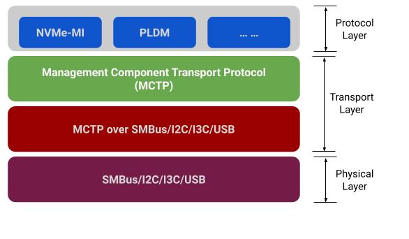

## 6.2 Protocol layers supported

### 6.2.1 MCTP

- Compliance with MCTP Base Protocol Specification

  i. The device will comply to all Endpoint requirements as specified in this section

  ii. For SMBus (Binding) Protocol, the device shall not be the MCTP Bus Owner

  iii. "The device shall support receiving an MCTP Set Endpoint ID command at any time (Standby or Main) power is applied. For example, the BMC firmware could be updated resulting in a BMC reset. The BMC initialization sequence will go out and dynamically discover devices and assign Endpoint IDs. While in most cases, the same Endpoint ID will be assigned, this is not guaranteed. The BMC will query the device to see if an Endpoint ID has been previously assigned and is not in conflict with any other assigned Endpoint.
- Specific compliance with Section “MCTP Message Types”
- Compliance with Section “MCTP Control Protocol”
- Compliance with Section “MCTP Control Messages”
- Support Section “MCTP Control Message Command Codes”, “MCTP Control Command Numbers”
- Support Section “Prepare for Endpoint Discovery”
- Support Section “Endpoint Discovery”

| MCTP Control Command (DSP0236) | Implementation |
| --- | --- |
| 0x01 Set Endpoint ID | Required |
| 0x02 Get Endpoint ID | Required |
| 0x03 Get Endpoint UUID | Required |
| 0x04 Get MCTP Version Support | Required |
| 0x05 Get Message Type Support | Required |
| 0x06=Get Vendor Defined Message Support | Required |
| 0x0B=Prepare for Endpoint Discovery | Required (PCIe VDM) |
| 0x0C=Endpoint Discovery | Required (PCIe VDM) |
| 0x0D=Discovery Notify | Required (PCIe VDM) |

### 6.2.2 PLDM

| PLDM Messaging Control and Discovery Command Codes (DSP0240) | Implementation |
| --- | --- |
| 0x01 SetTID | Required |
| 0x02 GetTID | Required |
| 0x03 GetPLDMVersion | Required |
| 0x04 GetPLDMTypes | Required |
| 0x05 GetPLDMCommands | Required |
| 0x06 SelectPLDMVersion | Required |
| 0x07 NegotiateTransferParameters | Required for PLDM FW Multipart |
| 0x08 MultipartSend | Required |
| 0x09 MultipartReceive | Required |

### 6.2.3 Redfish Device Enablement

Devices *shall* implement DSP0218 ([Platform Level Data Model (PLDM) for Redfish Device Enablement](https://www.dmtf.org/dsp/DSP0218))

Devices *shall* support 1 and should support a minimum of 4 concurrent RDE tree operations in parallel.

Devices should be capable of returning the requested portions of the Redfish tree in less than 2 seconds.

| RDE Command (DSP0218) |  | Implementation |
| --- | --- | --- |
| 0x01 NegotiateRedfishParameters |  | Required |
|  | DeviceCapabilitiesFlags | Support atomic resource read to enable consistent reads |
|  | DeviceFeatureSupport | Head and replace optional. Read mandatory. Other features are optional for inventory-only devices and mandatory for full support. |
|  | DeviceConfigurationSignature | Required as documented |
| 0x02 NegotiateMediumParameters |  | Required |
| 0x03 GetSchemaDictionary |  | Required |
| 0x04 GetSchemaURI |  | Required |
| 0x05 GetResourceETag |  | Required |
| 0x08 GetRegistryCount |  | Required for full event support |
| 0x09 GetRegistryDetails |  | Required for full event support |
| 0x0A SelectRegistryVersion |  | Required for full event support |
| 0x0B GetMessageRegistry |  | Required for full event support |
| 0x10 RDEOperationInit |  | Required for full event support |
|  | 0=OPERATION_HEAD | Required |
|  | 1=OPERATION_READ | Required |
|  | 2=OPERATION_CREATE | Conditional - Required for write support |
|  | 3=OPERATION_DELETE | Conditional - Required for write supportired |
|  | 4=OPERATION_UPDATE | Conditional - Required for write support |
|  | 6=OPRERATION_ACTION | Conditional - Required for write support |
| 0x11 SupplyCustomRequestParameters |  | Required |
| 0x12 RetrieveCustomResponseParameters |  | Required |
| 0x13 RDEOperationComplete |  | Required |
| 0x14 RDEOperationStatus |  | Required |
| 0x16 RDEOperationEnumerate |  | Required |
| 0x30 RDEMultipartSend |  | Required for write support |
| 0x31 RDEMultipartReceive |  | Required |

## 6.3 Device Identification

For purposes of identification, devices meeting this specification *shall* expose an interface to a Platform Management FRU Information Storage Definition-compatible API. The SMC API does not specify where this FRU payload must be physically implemented within the card. Implementations may choose to implement in a physical eeprom device, or a virtual eeprom device. Care should be taken in platform design to ensure that the eeprom is available in the required power states consistent with the needs of the baseline server, but this specification does not specify which power states it will be available in. Devices *shall* implement the following minimum fields.

**Product info area:**

- Manufacturer Name
- Product Name
- Product Serial Number

Other fields may be populated at the device's discretion.

## 6.4 Device Classes

The following device classes are supported: Accelerator, NIC, DPU (SmartNIC), Storage Tray, Memory (CXL).

# 7 API Surface

The below table calls out for the various device classes, whether a given feature is Required (R) or Conditional (C) on existence of the feature. For example, an Accelerator device may not have a Fan and thus Fan Control is conditional.

| Subsystem | Thermal | Inventory | Software Management | Fan Control | Security | Power Management |
| --- | --- | --- | --- | --- | --- | --- |
| *Accelerator* | R | R | R | C | R | C |
| *NICs* | C | R | R | C | R | C |
| *DPUs* | R | R | R | C | R | C |
| *Storage Tray* | C | R | R | C | R | C |
| *Memory (CXL)* | R | R | C | C | R | C |

## 7.1 Thermal management

The thermal management subsystem within this specification is intended to allow SMC devices to be managed by a system closed loop thermal system. Devices required to implement the thermal management subsystem *shall* implement the following Redfish resources and properties.

**Sensor**

An SMC SensorCollection *shall* implement one or more sensor resources representing the thermal temperature of the device. The sensor *shall* have the following properties supported.

- *ReadingUnits: Shall* be presented and implement as "Cel"
- *ReadingType: Shall* be present and implemented as “Temperature”
- Threshold properties of *UpperCritical*, *UpperFatal*, *LowerCritical*, and *LowerFatal* *shall* be implemented and represent the design limits of the SMC device in question. Devices with unlimited thermal design limits *shall* omit these properties.

If an SMC device possess fans, the SMC SensorCollection shall implement a Sensor with the following properties:

- *ReadingUnits: Shall* be present and implemented as “{rev}/min”
- *ReadingType: Shall* be present and implemented as “Rotational”

Devices implementing a single replaceable component may implement PLDM type 2 for sensor readings.

**PLDM Type 2 Sensor Requirements**

| PLDM for Platform Monitoring and Control (DSP0248) |  | Implementation |
| --- | --- | --- |
| Terminus Command |  |  |
|  | 0x04 SetEventReceiver | Required for RDE Alert |
|  | 0x05 GetEventReceiver | Required for RDE Alert |
|  | 0x0B PollForPlatformEventMessage | Required for RDE Alert |
|  | 0x0C EventMessageSupported | Required |
|  | 0x0D EventMessageBufferSize | Required for RDE Alert if MSG size > 256 bytes |
| Numeric Sensor Commands |  |  |
|  | 0x11 GetSensorReading | Required |
|  | 0x12 GenSensorThreshold | Required |
|  | 0x15 GetSensorHysteresis | Required |
| State Sensor Commands |  |  |
|  | 0x21 GetStateSensorReadings | Required |
| PDR Repository Commands |  |  |
|  | 0x50 GetPDRRepositoryInfo | Required |
|  | 0x51 GetPDR | Required |
|  | 0x53 GetPDRRepositorySignature | Required for RDE |
| PLDM Event Types |  |  |
|  | 0x02 redfishTaskExecutedEvent | Required if implementation cannot complete commands quickly enough to avoid spawning RDE tasks |
|  | 0x03 redfishMessageEvent | Required for redfish eventing |
|  | 0x51 GetPDR | Required for RDE |
| PDR Type Values |  |  |
|  | 2 = Numeric Sensor PDR | Required |
|  | 4= State Sensor PDR | Required |
|  | 22 = Redfish Resource PDR | Required for RDE |

Devices implementing multiple replaceable components shall implement ThermalSubsystem over RDE.

**ThermalSubsystem**

An SMC Redfish ThermalSubsystem *shall* be implemented, with the following properties:

- *Fans*: With Fan resources representing the fans physically present on this device.
- Fan resources *shall* contain the following properties
  - *SpeedPercent*

Requirements within this section are intended to allow inventory management and control of a given device. SMC devices *shall* implement:

**ChassisCollection**

SMC devices *may* implement more than one Chassis resource, for representing physical subsystems within the device. Within the SMC chassis collection, there *shall* be only one Chassis instance (referred to further as the “root”) that does not possess a ContainedBy attribute, and is intended to represent the overall containment of the device. All other devices *shall* have a ContainedBy Link, traceable to the root device. Root devices *shall* implement a “Contains” property representing the devices containment

## 7.2 Software Management

SMC devices implementing multiple updatable components shall implement an UpdateService. The SMC UpdateService shall implement one or more of FirmwareInventory, or SoftwareInventory collections. Collections shall contain at least one member of type SoftwareInventory, implementing the following properties

- **Version**: A string representing the software version running on the SMC device.
- **Updateable**: A property that conveys whether or not the device supports update. For SMC devices, this shall be set to True.
- **SoftwareID**: A property to uniquely identify this devices firmware type.
- **AdditionalVersions**: Devices that fit the Redfish descriptions in these properties shall implement AdditionalVersions, with the appropriate subproperties. Devices that do not fit the description shall omit the AdditionalVersions Property.

Devices implementing a single updatable component should implement updates of their firmware via PLDM type 5 ([DSP0267 Section 6](https://www.dmtf.org/dsp/DSP0267)).

| PLDM for Firmware Update DSP0267 | Implementation |
| --- | --- |
| 0x01 QueryDeviceIdentifiers | Required |
| 0x02 GetFirmwareParameters | Required |
| 0x03 QueryDownstreamDevices | Required |
| 0x04 QueryDowstreamIdentifiers | Required |
| 0x05 GetDownstreamFirmwareParameters | Required |
| 0x10 RequestUpdate | Required |
| 0x13 PassComponentTable | Required |
| 0x14 UpdateComponent | Required |
| 0x15 RequestFirmwareData | Required |
| 0x16 TransferComplete | Required |
| 0x17 VerifyComplete | Required |
| 0x18 ApplyComplete | Required |
| 0x1A ActivateFirmware | Required |
| 0x1B GetStatus | Required |
| 0x1B GetStatus | Required |
| 0x1C CancelUpdateComponent | Required |
| 0x1D CancelUpdate | Required |
| 0x20 RequestDownstreamDeviceUpdate | Required |

SMC devices shall be required to be updated in 1 minute or less, measured in the time that the device is unavailable, and 5 minutes or less from the time the update is requested, including all data transfers to the device.

## 7.3 Fan Control

SMC devices containing fans shall implement control and monitoring of those fans through the RDE interface. Devices shall support the Redfish Control schema for fan control within a system. SMC devices may run internal control loops in addition to the control loops presented on the RDE interface.

## 7.4 Power Management

If an SMC device supports reset, the Redfish Chassis.Reset action shall be supported.

If an SMC device captures power metrics, the SMC EnvironmentMetric and Sensor collection shall implement the following properties where supported:

- EnergykWh or EnergyJoules
- PowerWatts
- PowerLimitWatts
- ResetMetrics
- AverageReading
- AveragingInterval

## 7.5 Security

Sync with the OCP Security Group around these requirements is required. [Security Protocol and Data Model (SPDM) Specification](https://www.dmtf.org/dsp/DSP0274)

| SPDM Request Codes (DSP0274) |  | Implementation |
| --- | --- | --- |
| 0x81 GET_DIGESTS |  | Required |
| 0x82 GET_CERTIFCATE |  | Required |
| 0x83 CHALLENGE |  | Required |
| 0x84 GET_VERSION |  | Required |
| 0xE0 GET_MEASUREMENTS |  | Required |
|  | MEAS_CAP=10b | Required |
|  | DMTFSpecMeasurementValueType - [00h] Immutable Rom - [01h] Mutable FW | Required |
| 0xE1 GET_CAPABILITIES |  | Required |
|  | CERT_CAP | Required |
|  | CHAL_CAP | Required |
|  | MEAS_CAP | Required |
| 0xE3 NEGOTIATE_ALGORITHMS |  | Required |
|  | BaseAsymAlgo - [Bit 2] TPM_ALG_RSASSA_3072 [CMA, CNSA,OCP] (Allowed) - [Bit 4) TPM_ALG_ECDSA_ECC_NIST_P256[CMA] (Allowed) - [Bit 7] TPM_ALG_ECDSA_ECC_NIST_P384[CMA, CNSA, OCP] (Preferred) |  |
|  | BaseHashAlgo - [Bit 0] TPM_ALG_SHA_256 [CMA] (Allowed) - [Bit 1] TPM_ALG_SHA_384 [CMA, CNSA, OCP] (Preferred) |  |
|  | MeasurementHashAlgo - [Bit 1] TPM_ALG_SHA_256 [CMA] (Allowed) - [Bit 2] TPM_ALG_SHA_384 [CMA, CNSA, OCP] (Preferred) |  |
| 0xFF RESPOND_IF_READY |  | Required |

**Security Requirements**

SPDM 1.1 or later is required. The following attributes shall be supported:

- Authentication
- Identification
- Attestation

# 8 Glossary of Terms

This section provides definitions for terms used in this document.

**Server**. Machine hardware that contains a Satellite plug-in. Satellite containers are typically Servers but are not required to be so. So we use the more general term Host for a Satellite container.

**Host**. A generalization of a Satellite container that includes Servers (for PCIe Plug-In Satellites) and motherboards (for SoC Satellites). A Host is managed by a logical Host Management Controller (HMC).

**Satellite**. A dependent group of hardware that is managed by a logical Satellite Management Controller (SMC). Satellites typically are smaller than their Host, are terminal points in the management graph, and contain a single power & thermal domain.

**SMC**. Satellite Management Controller provides a management API to Satellite hardware. SMCs may be backed by one or more discrete hardware components. SMC is typically a low-cost ARM microcontroller running a RTOS with no external DRAM, although this is not prescriptive and any CPU architecture and configuration is acceptable.

**Terminal Hardware**. Hardware that is an endpoint in the management graph. In other words, terminal hardware does not itself manage other hardware. Satellites are terminal hardware.

# 9 References

- DMTF DSP0218 - [Platform Level Data Model (PLDM) for Redfish Device Enablement](https://www.dmtf.org/dsp/DSP0218)
- DMTF DSP0233 - [Management Component Transport Protocol (MCTP) I3C Transport Binding Specification](https://www.dmtf.org/dsp/DSP0233)
- DMTF DSP0236 - [Management Component Transport Protocol (MCTP) Base Specification](https://www.dmtf.org/dsp/DSP0236)
- DMTF DSP0237 - [Management Component Transport Protocol (MCTP) SMBus/I2C Transport Binding Specification](https://www.dmtf.org/dsp/DSP0237)
- DMTF DSP0238 - [Management Component Transport Protocol (MCTP) PCIe VDM Transport Binding Specification](https://www.dmtf.org/dsp/DSP0238)
- DMTF DSP0240 - [Platform Level Data Model (PLDM) Base Specification](https://www.dmtf.org/dsp/DSP0240)
- DMTF DSP0241 - [Platform Level Data Model (PLDM) Over MCTP Binding Specification](https://www.dmtf.org/dsp/DSP0241)
- DMTF DSP0248 - [Platform Level Data Model (PLDM) for Platform Monitoring and Control Specification](https://www.dmtf.org/dsp/DSP0248)
- DMTF DSP0267 - [Platform Level Data Model (PLDM) for Firmware Update Specification](https://www.dmtf.org/dsp/DSP0267)
- DMTF DSP0274 - [Security Protocol and Data Model (SPDM) Specification](https://www.dmtf.org/dsp/DSP0274)